# Predicting House Prices in Boulder

Veronica Rosado & Weslene Uy

10/22/2021

# Introduction

This project aims to develop a model that could predict home values in Boulder County, Colorado by using geospatial machine learning processes. We identified different indicators that could influence home values. Market rates and economic valuation under capitalist systems are based on geographical factors. For example, a home’s location and its access to amenities and services might influence its valuation. Price differences could also arise based on a home’s qualities, such as the size of its livable areas, design, and the construction material used. Demographic variables such as race and income also contribute to home value disparities.

Because some data sets are unavailable or unreliable, and since our estimates are only as good as the data that is fed into the model, our predicted home values are not entirely accurate. There are also several other factors that determine home values, some of which are difficult to quantify, and are therefore excluded from our analysis. Despite these limitations, our model still provides a useful ballpark estimate for those looking to purchase or refinance their properties.

## Methodology and Modeling Strategy

The Boulder County Assessor’s Office publicly releases property data, which includes home sale prices and building characteristics. This property data set will be used to develop our model. We gathered data on some variables that could affect property values from Boulder Open Data, Open Street Map, and the U.S. Census. These variables were then grouped into two broad categories: internal and external characteristics. External characteristics variables were further processed to determine how far a home is to certain amenities and whether it is located in a disaster-prone area.

Following this, we explored and visualized the relationship of home prices to both internal and external variables. Variables that were highly associated with each other were excluded from our model since it would be difficult to determine their unique effect on home values. Afterwards, we split the data into a training set and a test set. The training data is used to develop our model, while the test set assesses how well our model is able predict home sale prices for Boulder County. Finally, we evaluate our model for generalizability to check if it still does a good job predicting home values under different contexts.

Table of data sets

| Dataset | Description | Open Data URL | File Type | Location |
| --- | --- | --- | --- | --- |
| Boulder County Municipalities | Boundaries polygons | https://opendata-bouldercounty.hub.arcgis.com/datasets/bouldercounty::municipalities/about | geojson | MUSA-508/Midterm |
| Boulder County Boundary | Boundary polygon | https://opendata-bouldercounty.hub.arcgis.com/datasets/county-boundary/explore?location=40.088157%2C-105.373097%2C11.58 | geojson | MUSA-508/Midterm |
| Parks | Boundaries for parks and open spaces state and municipally owned | https://opendata-bouldercounty.hub.arcgis.com/datasets/county-open-space/explore?location=40.080100%2C-105.341850%2C11.48&showTable=true | geojson | MUSA-508/Midterm |
| Student Data | Homes data for Boulder County (2019-2021) | Provided by MUSA508 instructors | geojson | MUSA-508/Midterm |
| Libraries | Points of libraries in Boulder County | https://opendata.arcgis.com/datasets/7f4ea25ba87345e380d2e896611d2588_0.geojson | geojson | Boulder County Open Data |
| Restaurants | 5 year ACS 2019 | osmdata package | geojson | OSM |
| Marijuana Establishments | Point data for establishments locations | https://www.bouldercounty.org/government/open-data/ | geojson | MUSA-508/Midterm |
| Schools | Point data of elementary, middle and high schools | https://www.bouldercounty.org/government/open-data/ | geojson | MUSA-508/Midterm |
| Universities | 5 year ACS 2019 | osmdata package | geojson | OSM |
| Healthcare | Clinics and hospitals point data | osmdata package | geojson | OSM |
| Trails | Trails from Open Spaces & Parks | https://www.bouldercounty.org/government/open-data/ | geojson | MUSA-508/Midterm |
| Flood zones | Inundated high water maker for the Boulder County flood | https://www.bouldercounty.org/government/open-data/ | geojson | MUSA-508/Midterm |
| Scenic corridors | Boulder County Peak to Peak Corridor | https://www.bouldercounty.org/government/open-data/ | geojson | MUSA-508/Midterm |

## Summary of results

Highlights of our model’s results:

• The model errors by 25%, predicting a difference of over 100k, thus we consider it is not reliable for predicting home prices for Zillow. The selected features though, could be further examined to develop a more better model. Our model had little colinearity between the descriptive variables, which is an essential step into improving prediction ML models.

## Getting Started: Data

### Property Values Data Set

```r
muni <-
  st_read("~/CPLNPennDesign/590-Musa/Musa508-Vero/MUSA-508/Midterm/Municipalities.geojson") %>%
  st_transform('ESRI:102653')

housingData <-
  st_read("~/CPLNPennDesign/590-Musa/Musa508-Vero/MUSA-508/Midterm/studentData.geojson", crs = 'ESRI:102254') %>%
  st_transform('ESRI:102653')

boulderCounty <-
  st_read("~/CPLNPennDesign/590-Musa/Musa508-Vero/MUSA-508/Midterm/County_Boundary.geojson")%>%
  st_transform('ESRI:102653')

boulder.sf <- housingData %>%
  st_as_sf(coords = c("Longitude", "Latitude"), crs = 4326, agr = "constant") %>%
  st_transform('ESRI:102653') %>%
  mutate(pricesqft = ifelse(TotalFinishedSF > 0, (price/TotalFinishedSF), 0),
    TotalBathrooms = nbrThreeQtrBaths + nbrFullBaths + nbrHalfBaths) %>%
  rename(Size = TotalFinishedSF,
         TotalBedrooms = nbrBedRoom,
         GarageSize = carStorageSF,
         BuildingType = designCodeDscr,
         Quality = qualityCodeDscr,
         YearBuilt = EffectiveYear,
         Construction = ConstCodeDscr,
         Interior = IntWallDscr)


#State Plane Colorado - ESRI:102653
#Colorado North - ESRI:102253
#Colorado Central - ESRI:102254
#Boulder - SR-ORG:7992
```

### Feature Engineering

We recategorized some variables to avoid outliers. This is meant to potentially improve our model’s predictive power. Since less than 40 homes had 7 to 24 bedrooms, while over 4,000 houses had 3, homes with at least 7 bedrooms were grouped together with houses that have 6 bedrooms (6+ category). For bathrooms, a similar recategorization was done. Homes that have at least 5 bathrooms were lumped together in one category.

| Na | Brick | Concrete | Frame | Masonry | Precast | Veneer | Wood |
| --- | --- | --- | --- | --- | --- | --- | --- |
| 75 | 125 | 6 | 9625 | 1526 | 2 | 1 | 4 |

We also recategorized both construction materials and the interior types into more general categories. Homes built with bricks, concrete, masonry, and precast were grouped under “stone based”, while the rest fell under the “Non-stone based” category. For interior wall materials, we decided to recategorize them into “drywall” and “other” categories.

| Na | Drywall | Hardwood Panel | Plaster | Plywood | Unfinished | Wall Board |
| --- | --- | --- | --- | --- | --- | --- |
| 79 | 10411 | 185 | 482 | 32 | 40 | 135 |

```r
#Total Bedrooms
boulder.sf <-
  boulder.sf %>%
  mutate(TotalBedrooms.cat = case_when(
                  TotalBedrooms == 0   ~ "0",
                  TotalBedrooms == 1   ~ "1",
                  TotalBedrooms == 2   ~ "2",
                  TotalBedrooms == 3   ~ "3",
                  TotalBedrooms == 4   ~ "4",
                  TotalBedrooms == 5   ~ "5",
                  TotalBedrooms >=6    ~ "6+ "))
#Total Bathrooms
boulder.sf <-
  boulder.sf %>%
  mutate(TotalBathrooms.cat = case_when(
                  TotalBathrooms == 0   ~ "0",
                  TotalBathrooms == 1   ~ "1",
                  TotalBathrooms == 2   ~ "2",
                  TotalBathrooms == 3   ~ "3",
                  TotalBathrooms == 4   ~ "4",
                  TotalBathrooms >= 5   ~ "5+"))
#Construction
boulder.sf <-
  boulder.sf %>%
  mutate(Construction = case_when(
                  Construction == 'Masonry' | Construction== 'Precast' | Construction=='Concrete' | Construction=='Brick'   ~ "Stone based",
                  Construction == 'Wood' | Construction=='Veneer' | Construction=='Frame'   ~ "Non-stone based"))

#Interior
boulder.sf <-
  boulder.sf %>%
  mutate(Interior = case_when(
                  Interior == 'Drywall' ~ "Drywall", TRUE ~ "Other"))
```

## What internal and external factors influence home value?

### Internal Characteristics

We selected a few variables that we believe would be good price predictors for homes in Boulder County. Appraisers typically look at the home’s structure as well as its condition. The following housing characteristics were included in our model: the appraisers’ assessment of the building quality, total size, garage size, building classification, effective year built to account for remodeling through the years, number of bedrooms and bathrooms, and the materials used to construct the house.

### External Characteristics

Based on the demographics, it is a relatively white county, with over 85% of the population being white. median income rates are also high in about 80k for median income, doubling the national average. This should explain why ownership is higher than rented homes for example. Most people seem to drive to work, and the average commute in the county is 23 minutes. Parks and open spaces are an important highlight of Boulder County as well. These amenities are an attraction to both locals and tourists, probably becoming a strong factor influencing home values relative to their proximity. Physical activity and access to green trails seems important for households in Boulder County? A survey by the Centers for Disease Control found that Colorado had fewer overweight people per capita and more people who exercise than any other state. While most people commute by car to jobs and amenities, it seems that physical activity is described through these natural assets. In a post COVID/work from home scenario, access to these sites might be a strong variable for home price. Based on census and fast facts, education, health and leisure seem a priority for Boulder County citizens. Distance to amenities such as schools, colleges, universities, and restaurants are also considered in this project.

### Demographic Variables

```r
# Load census API key
census_api_key("7fcf0c60997f4d8ccd298e26df0b2f35dc033150",install=TRUE, overwrite=TRUE)

#Load list of variables
acs_variable_list.2019 <- load_variables(2019,"acs5")


#Year 2019 tracts
tracts19 <-
  get_acs(geography = "tract", variables = c("B25026_001E","B19013_001E","B01002_001E","B02001_002"),
          year=2019, state=08, county=013, geometry=T) %>%
  st_transform('ESRI:102653')

tracts19 <-
  tracts19 %>%
  select( -NAME, -moe) %>%
  spread(variable, estimate) %>%
  select(-geometry) %>%
  rename(TotalPop = B25026_001,
         MedHHInc = B19013_001,
         medianage = B01002_001,
         WhitePop = B02001_002)

tracts19 <-
  tracts19 %>%
  mutate(pctWhite = ifelse(TotalPop > 0, WhitePop / TotalPop, 0))

#point to polygon spatial join
boulder.sf <-
  boulder.sf  %>%
    mutate(
      st_join(boulder.sf, tracts19, join = st_within))
```

### Amenities + Public Services + Hazards

```r
library(osmdata)
library(tigris)

q0 <- opq(bbox = c("Boulder County")) #bounding box for boulder

#Libraries

libraries <-
   st_read("https://opendata.arcgis.com/datasets/7f4ea25ba87345e380d2e896611d2588_0.geojson") %>%
  st_transform(st_crs('ESRI:102653'))

#Trails

trails <-
   st_read("https://opendata.arcgis.com/datasets/3a950053bbef46c6a3c2abe3aceee3de_0.geojson") %>%
  st_transform(st_crs('ESRI:102653'))

trails <- st_intersection(boulderCounty, trails)

#---- Marihuana Establishments -----

marijuanaestablishments <-
   st_read("https://opendata.arcgis.com/datasets/425a0adb547a4faba4b741a4fe4373b1_0.geojson") %>%
  st_transform(st_crs('ESRI:102653'))


# ----- Schools + Universities----

schools <-
  st_read("~/CPLNPennDesign/590-Musa/Musa508-Vero/MUSA-508/Midterm/Schools_Boulder.shp") %>%
  st_transform('ESRI:102653')

university <- add_osm_feature(opq = q0, key = 'amenity', value = "university") %>%
  osmdata_sf(.)
university.sf <- st_geometry(university$osm_points) %>%
  st_transform(4326) %>%
  st_sf() %>%
  cbind(., university$osm_points$osm_id) %>%
  rename(NAME = university.osm_points.osm_id)

#---- Parks ----

parks <-
  st_read("~/CPLNPennDesign/590-Musa/Musa508-Vero/MUSA-508/Midterm/County_Open_Space.geojson") %>%
  filter(!is.na(PARK_GROUP)) %>%
  st_transform('ESRI:102653')


# ----- Hospitals + Clinics ----
hospitals <- add_osm_feature(opq = q0, key = 'amenity', value = "hospital") %>%
  osmdata_sf(.)
hospitals.sf <- st_geometry(hospitals$osm_points) %>%
  st_transform(4326) %>%
  st_sf() %>%
  cbind(., hospitals$osm_points$amenity) %>%
  rename(NAME = hospitals.osm_points.amenity)

clinics <- add_osm_feature(opq = q0, key = 'amenity', value = "clinic") %>%
  osmdata_sf(.)
clinics.sf <- st_geometry(clinics$osm_points) %>%
  st_transform(4326) %>%
  st_sf() %>%
  cbind(., clinics$osm_points$amenity) %>%
  rename(NAME = clinics.osm_points.amenity)

healthcare <- rbind(hospitals.sf,clinics.sf)

healthcare <- st_intersection(boulderCounty %>% st_transform(4326), healthcare)


#---- Restaurants -----
restaurant <- add_osm_feature(opq = q0, key = 'amenity', value = "restaurant") %>%
  osmdata_sf(.)
restaurant.sf <- st_geometry(restaurant$osm_points) %>%
  st_transform(4326) %>%
  st_sf() %>%
  cbind(., restaurant$osm_points$amenity) %>%
  rename(NAME = restaurant.osm_points.amenity)

restaurant.sf <- st_intersection((boulderCounty) %>% st_transform(4326), restaurant.sf)

#---- Disaster Risks -----
sceniccorridor <-
   st_read("https://opendata.arcgis.com/datasets/749ed0a11e454f64a0e5f7c51a786129_0.geojson") %>%
   st_transform(st_crs('ESRI:102653'))

floodzones <-
   st_read("https://opendata.arcgis.com/datasets/a9624bd25d854ef7ab0d543e9490ce48_0.geojson") %>%
   st_transform(st_crs('ESRI:102653'))

wildfires <-
   st_read("https://opendata.arcgis.com/datasets/61f20f4a64274969a9e740eda5c62de7_0.geojson") %>%
   st_transform(st_crs('ESRI:102653'))


#---- Adding features to the home data ----

st_c <- st_coordinates

#libraries
boulder.sf <-
  boulder.sf  %>%
    mutate(
      libraries_nn1 = nn_function(st_c(boulder.sf), st_c(libraries), 1),
      libraries_nn2 = nn_function(st_c(boulder.sf), st_c(libraries), 2),
      libraries_nn3 = nn_function(st_c(boulder.sf), st_c(libraries), 3),
      libraries_nn4 = nn_function(st_c(boulder.sf), st_c(libraries), 4),
      libraries_nn5 = nn_function(st_c(boulder.sf), st_c(libraries), 5))

#trails
boulder.sf <-
  boulder.sf  %>%
    mutate(
      trails_nn1 = nn_function(st_c(boulder.sf), st_c(trails), 1),
      trails_nn2 = nn_function(st_c(boulder.sf), st_c(trails), 2),
      trails_nn3 = nn_function(st_c(boulder.sf), st_c(trails), 3),
      trails_nn4 = nn_function(st_c(boulder.sf), st_c(trails), 4),
      trails_nn5 = nn_function(st_c(boulder.sf), st_c(trails), 5))

#marijuana establishments
boulder.sf <-
  boulder.sf  %>%
    mutate(
      marijuanaestablishments_nn1 = nn_function(st_c(boulder.sf), st_c(marijuanaestablishments), 1),
      marijuanaestablishments_nn2 = nn_function(st_c(boulder.sf), st_c(marijuanaestablishments), 2),
      marijuanaestablishments_nn3 = nn_function(st_c(boulder.sf), st_c(marijuanaestablishments), 3),
      marijuanaestablishments_nn4 = nn_function(st_c(boulder.sf), st_c(marijuanaestablishments), 4),
      marijuanaestablishments_nn5 = nn_function(st_c(boulder.sf), st_c(marijuanaestablishments), 5))

#schools (elementary school, middle school, high school)
boulder.sf <-
  boulder.sf  %>%
    mutate(
      schools_nn1 = nn_function(st_c(boulder.sf), st_c(schools), 1),
      schools_nn2 = nn_function(st_c(boulder.sf), st_c(schools), 2),
      schools_nn3 = nn_function(st_c(boulder.sf), st_c(schools), 3),
      schools_nn4 = nn_function(st_c(boulder.sf), st_c(schools), 4),
      schools_nn5 = nn_function(st_c(boulder.sf), st_c(schools), 5))

#university
boulder.sf <-
  boulder.sf  %>%
    mutate(
      university_nn1 = nn_function(st_c(boulder.sf), st_c(university.sf), 1),
      university_nn2 = nn_function(st_c(boulder.sf), st_c(university.sf), 2),
      university_nn3 = nn_function(st_c(boulder.sf), st_c(university.sf), 3),
      university_nn4 = nn_function(st_c(boulder.sf), st_c(university.sf), 4),
      university_nn5 = nn_function(st_c(boulder.sf), st_c(university.sf), 5))

# Parks
parks.sf <- st_centroid(parks)

boulder.sf <-
  boulder.sf  %>%
    mutate(
      parks_nn1 = nn_function(st_c(boulder.sf), st_c(parks.sf),1),
      parks_nn2 = nn_function(st_c(boulder.sf), st_c(parks.sf), 2),
      parks_nn3 = nn_function(st_c(boulder.sf), st_c(parks.sf), 3),
      parks_nn4 = nn_function(st_c(boulder.sf), st_c(parks.sf), 4),
      parks_nn5 = nn_function(st_c(boulder.sf), st_c(parks.sf), 5))

#healthcare facilities
boulder.sf <-
  boulder.sf  %>%
    mutate(
      healthcare_nn1 = nn_function(st_c(boulder.sf), st_c(healthcare), 1),
      healthcare_nn2 = nn_function(st_c(boulder.sf), st_c(healthcare), 2),
      healthcare_nn3 = nn_function(st_c(boulder.sf), st_c(healthcare), 3),
      healthcare_nn4 = nn_function(st_c(boulder.sf), st_c(healthcare), 4),
      healthcare_nn5 = nn_function(st_c(boulder.sf), st_c(healthcare), 5))

#restaurants
boulder.sf <-
  boulder.sf  %>%
    mutate(
      restaurant_nn1 = nn_function(st_c(boulder.sf), st_c(restaurant.sf), 1),
      restaurant_nn2 = nn_function(st_c(boulder.sf), st_c(restaurant.sf), 2),
      restaurant_nn3 = nn_function(st_c(boulder.sf), st_c(restaurant.sf), 3),
      restaurant_nn4 = nn_function(st_c(boulder.sf), st_c(restaurant.sf), 4),
      restaurant_nn5 = nn_function(st_c(boulder.sf), st_c(restaurant.sf), 5))

#floodzones
floodzones <-
  floodzones %>%
  mutate(floodzone = 1) %>%
  select(OBJECTID, StreamName, geometry, floodzone)

boulder.sf <-
  st_join(boulder.sf, floodzones, join = st_within)

boulder.sf$floodzones =
  ifelse(is.na(boulder.sf$floodzone),0, 1)


#scenic corridor
sceniccorridor <-
  sceniccorridor %>%
  mutate(sceniccorridor = 1) %>%
  select(OBJECTID, geometry, sceniccorridor)


boulder.sf <-
  st_join(boulder.sf, sceniccorridor)

boulder.sf$sceniccorridor =
  ifelse(is.na(boulder.sf$sceniccorridor),0, 1)


#wildfire
wildfires <-
 wildfires %>%
 mutate(wildfire = 1)

boulder.sf <-
  st_join(boulder.sf, wildfires)
boulder.sf$wildfires =
  ifelse(is.na(boulder.sf$wildfire),0, 1)
```

## Mapping the variables

The map below visualizes the home sale prices in the county. Higher sale prices are clustered in Boulder City, as well as the areas surrounding it.

### Home prices spatially distributed across Boulder County.

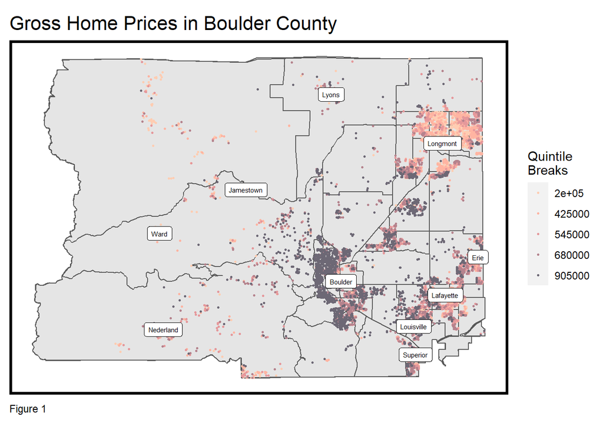

```r
boulder.sf <- boulder.sf %>% drop_na(price)

ggplot() +
  geom_sf(data = boulderCounty, fill = "grey90") +
  geom_sf(data = tracts19, fill = NA) +
  geom_sf(data = boulder.sf, aes(colour = q5(price)),
          show.legend = "point", size = .5) +
  scale_color_manual(values = palette5,
                   labels = qBr(boulder.sf, "price"),
                   name = "Quintile\nBreaks") +
  geom_sf_label(data = muni, aes(label = ZONEDESC), size = 2) +
  labs(title="Gross Home Prices in Boulder County",
       caption="Figure 1") +
  mapTheme()
```